# Botanical research CV project

```python
from google.colab import drive
drive.mount('/content/drive')
```

```python
import warnings
warnings.filterwarnings('ignore')
import os
import numpy as np
import tensorflow as tf
```

```python
import cv2
Test_set = '/content/drive/MyDrive/CNN- Project 1(Botanical research)/Dataset - Plant-seedlings-classification/test'
Train_set= '/content/drive/MyDrive/CNN- Project 1(Botanical research)/Dataset - Plant-seedlings-classification/train'
Train_Black_grass = '/content/drive/MyDrive/CNN- Project 1(Botanical research)/Dataset - Plant-seedlings-classification/train/Black-grass'
Train_Charlock= '/content/drive/MyDrive/CNN- Project 1(Botanical research)/Dataset - Plant-seedlings-classification/train/Charlock'
```

```python
Train_Common_Chickweed = Train_set + '/Common Chickweed'
Train_Cleavers = Train_set + '/Cleavers'
Train_Small_flowered_Cranesbill = Train_set + '/Small-flowered Cranesbill'
Train_Scentless_Mayweed = Train_set + '/Scentless Mayweed'
Train_Shepherds_Purse = Train_set + '/Shepherds Purse'
Train_Fat_Hen = Train_set + '/Fat Hen'
Train_Common_wheat = Train_set + '/Common wheat'
Train_Maize = Train_set + '/Maize'
Train_Loose_Silky_bent = Train_set + '/Loose Silky-bent'
Train_Sugar_beet = Train_set + '/Sugar beet'
```

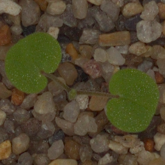

```python
#displaying one image form the Test_set
from google.colab.patches import cv2_imshow
img = cv2.imread(Test_set + '/0021e90e4.png')
img1 = cv2.imread(Train_Black_grass + '/0050f38b3.png')
img2 = cv2.imread(Train_Charlock + '/022179d65.png')
cv2_imshow(img)
```

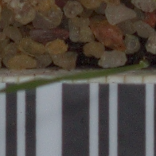

```python
cv2_imshow(img1)
```

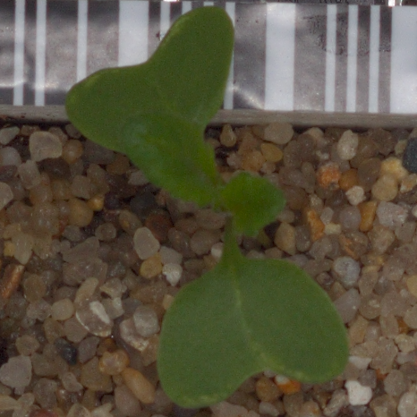

```python
cv2_imshow(img2)
```

```python
#Reading images from 'Train_Black_grass' folder and creating labels ( Labels for this class should be 0 )
Black_grass_img = []
y_Black_grass = []

os.chdir(Train_Black_grass)

import cv2
for i in os.listdir(Train_Black_grass):
  a = cv2.imread(i)
  a = cv2.resize(a,(128,128))
  Black_grass_img.append(a)
  y_Black_grass.append(0)
```

```python
#Reading images from 'Train_Charlock' folder and creating labels ( Labels for this class is 1 )
Charlock_img = []
y_Charlock = []

os.chdir(Train_Charlock)

import cv2
for i in os.listdir(Train_Charlock):
  a = cv2.imread(i)
  a = cv2.resize(a,(128,128))
  Charlock_img.append(a)
  y_Charlock.append(1)
```

```python
#Reading images from 'Train_Common_Chickweed' folder and creating labels ( Labels for this class should be 2 )
Common_Chickweed_img = []
y_Common_Chickweed = []

os.chdir(Train_Common_Chickweed)

for i in os.listdir(Train_Common_Chickweed):
  a = cv2.imread(i)
  a = cv2.resize(a,(128,128))
  Common_Chickweed_img.append(a)
  y_Common_Chickweed.append(2)
```

```python
#Reading images from 'Train_Cleavers' folder and creating labels ( Labels for this class should be 3)
Cleavers_img = []
y_Cleavers = []

os.chdir(Train_Cleavers)

for i in os.listdir(Train_Cleavers):
  a = cv2.imread(i)
  a = cv2.resize(a,(128,128))
  Cleavers_img.append(a)
  y_Cleavers.append(3)
```

```python
 #Reading images from 'Train_Small_flowered_Cranesbill' folder and creating labels ( Labels for this class should be 4 )
Small_flowered_Cranesbill_img = []
y_Small_flowered_Cranesbill = []

os.chdir(Train_Small_flowered_Cranesbill)

for i in os.listdir(Train_Small_flowered_Cranesbill):
  a = cv2.imread(i)
  a = cv2.resize(a,(128,128))
  Small_flowered_Cranesbill_img.append(a)
  y_Small_flowered_Cranesbill.append(4)

  #Reading images from 'Train_Scentless_Mayweed' folder and creating labels ( Labels for this class should be 5 )
Scentless_Mayweed_img = []
y_Scentless_Mayweed = []

os.chdir(Train_Scentless_Mayweed)

for i in os.listdir(Train_Scentless_Mayweed):
  a = cv2.imread(i)
  a = cv2.resize(a,(128,128))
  Scentless_Mayweed_img.append(a)
  y_Scentless_Mayweed.append(5)
```

```python
#Reading images from 'Train_Shepherds_Purse' folder and creating labels ( Labels for this class should be 6 )
Shepherds_Purse_img = []
y_Shepherds_Purse = []

os.chdir(Train_Shepherds_Purse)

for i in os.listdir(Train_Shepherds_Purse):
  a = cv2.imread(i)
  a = cv2.resize(a,(128,128))
  Shepherds_Purse_img.append(a)
  y_Shepherds_Purse.append(6)
```

```python
#Reading images from 'Train_Fat_Hen' folder and creating labels ( Labels for this class should be 7 )
Fat_Hen_img = []
y_Fat_Hen = []

os.chdir(Train_Fat_Hen)

for i in os.listdir(Train_Fat_Hen):
  a = cv2.imread(i)
  a = cv2.resize(a,(128,128))
  Fat_Hen_img.append(a)
  y_Fat_Hen.append(7)
```

```python
 #Reading images from 'Train_Common_wheat' folder and creating labels ( Labels for this class should be 8 )
Common_wheat_img = []
y_Common_wheat= []

os.chdir(Train_Common_wheat)

for i in os.listdir(Train_Common_wheat):
  a = cv2.imread(i)
  a = cv2.resize(a,(128,128))
  Common_wheat_img.append(a)
  y_Common_wheat.append(8)
```

```python
#Reading images from 'Train_Maize' folder and creating labels ( Labels for this class should be 9 )
Maize_img = []
y_Maize = []

os.chdir(Train_Maize)

for i in os.listdir(Train_Maize):
  a = cv2.imread(i)
  a = cv2.resize(a,(128,128))
  Maize_img.append(a)
  y_Maize.append(9)
```

```python
  #Reading images from 'Train_Loose_Silky_bent' folder and creating labels ( Labels for this class should be 10 )
Loose_Silky_bent_img = []
y_Loose_Silky_bent = []

os.chdir(Train_Loose_Silky_bent)

for i in os.listdir(Train_Loose_Silky_bent):
  a = cv2.imread(i)
  a = cv2.resize(a,(128,128))
  Loose_Silky_bent_img.append(a)
  y_Loose_Silky_bent.append(10)

  #Reading images from 'Train_Sugar_beet' folder and creating labels ( Labels for this class should be 11 )
Sugar_beet_img = []
y_Sugar_beet = []

os.chdir(Train_Sugar_beet)

for i in os.listdir(Train_Sugar_beet):
  a = cv2.imread(i)
  a = cv2.resize(a,(128,128))
  Sugar_beet_img.append(a)
  y_Sugar_beet.append(11)
```

```python
print(Loose_Silky_bent_img[1].shape)
print(len(Loose_Silky_bent_img))
```

```
(128, 128, 3)
654
```

```python
print(Sugar_beet_img[1].shape)
print(len(Sugar_beet_img))
```

```
(128, 128, 3)
385
```

```python
X_img = np.concatenate((Black_grass_img,Charlock_img, Common_Chickweed_img, Cleavers_img, Small_flowered_Cranesbill_img, Scentless_Mayweed_img, Shepherds_Purse_img, Fat_Hen_img, Common_wheat_img, Maize_img, Loose_Silky_bent_img, Sugar_beet_img), axis=0)

# Checking  shape and size of data after concatenation

print(X_img.shape)
```

```
(4750, 128, 128, 3)
```

```python
Y = np.concatenate((y_Black_grass, y_Charlock, y_Common_Chickweed, y_Cleavers, y_Small_flowered_Cranesbill, y_Scentless_Mayweed, y_Shepherds_Purse, y_Fat_Hen, y_Common_wheat, y_Maize, y_Loose_Silky_bent, y_Sugar_beet), axis=0)

# Checking  shape and size of data after concatenation

print(Y.shape)
```

```
(4750,)
```

```python
from sklearn.utils import shuffle
data, label = shuffle(X_img, Y, random_state = 9)
```

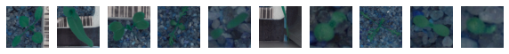

```
Label for each of the above images is: [2 9 1 5 7 0 5 5 5 5]
```

```python
%matplotlib inline

import matplotlib.pyplot as plt

plt.figure(figsize=(10, 1))
for i in range(10):
        plt.subplot(1, 10, i+1)
        plt.imshow(data[i],cmap='gray')
        plt.axis('off')
plt.show()

print('Label for each of the above images is: %s' % (label[0:10]))
```

```python
from sklearn.model_selection import train_test_split

X_train, X_test, y_train, y_test = train_test_split( data, label, test_size=0.25, random_state=9)
```

```python
print(X_train.shape)
print(X_test.shape)
```

```
(3562, 128, 128, 3)
(1188, 128, 128, 3)
```

```python
#Normalize the values to appear between 0 and 1

X_train_std = X_train/255.0
X_test_std = X_test/255.0
```

```python
X_train_std.shape
```

```
(3562, 128, 128, 3)
```

```python
X_test_std.shape
```

```
(1188, 128, 128, 3)
```

```python
from tensorflow.keras.utils import to_categorical

y_train_oh = to_categorical(y_train)
y_test_oh = to_categorical(y_test)

print(y_train_oh.shape)
print(y_test_oh.shape)
```

```
(3562, 12)
(1188, 12)
```

Model building

SVM Model

```python
from sklearn import svm
from sklearn.preprocessing import StandardScaler
```

```python
nsamples, nx, ny, rb = X_train_std.shape
d2_train_dataset = X_train_std.reshape((nsamples,nx*ny*rb))
```

```python
sc = StandardScaler()
X_centered = sc.fit_transform(d2_train_dataset)
```

```python
from sklearn.decomposition import PCA

pca = PCA(n_components=6)
X_pca = pca.fit_transform(X_centered)
```

```python
clf = svm.SVC(gamma=0.21)
clf.fit(X_pca, y_train)
```

```
SVC(C=1.0, break_ties=False, cache_size=200, class_weight=None, coef0=0.0,
    decision_function_shape='ovr', degree=3, gamma=0.21, kernel='rbf',
    max_iter=-1, probability=False, random_state=None, shrinking=True,
    tol=0.001, verbose=False)
```

```python
nsamples, nx, ny, rb = X_test_std.shape
d2_test_dataset = X_test_std.reshape((nsamples,nx*ny*rb))
sc = StandardScaler()
X_c = sc.fit_transform(d2_test_dataset)
pca = PCA(n_components=6)
X_pca_t = pca.fit_transform(X_c)
```

```python
predicted = clf.predict(X_pca_t)
```

```python
from sklearn.metrics import accuracy_score
accuracy_score(y_test, predicted)
```

```
0.1388888888888889
```

Neural Network Model

```python
x_train_NN = np.asarray(X_train_std).reshape(3562, 49152)
```

```python
X_test_NN = np.asarray(X_test_std).reshape(1188, 49152)
```

```python
x_train_NN.shape
```

```
(3562, 49152)
```

```python
model = tf.keras.models.Sequential()

model.add(tf.keras.layers.BatchNormalization())
model.add(tf.keras.layers.Dense(400, activation= "relu"))
model.add(tf.keras.layers.Dense(200, activation= "relu"))
model.add(tf.keras.layers.Dropout(0.25))
model.add(tf.keras.layers.Dense(12,activation="softmax"))
```

```python
model.compile(optimizer='sgd', loss='categorical_crossentropy',metrics=['accuracy'])
```

```python
earlystopping= tf.keras.callbacks.EarlyStopping(monitor='val_loss', patience= 2, restore_best_weights= True)
```

```python
history = model.fit(x_train_NN,y_train_oh, validation_data=(X_test_NN,y_test_oh), epochs=20, batch_size= 50, callbacks=earlystopping)
```

[output not shown]

CNN Model

```python
epochs = 20
batch_size = 32
n_classes = 12
```

```python
from tensorflow.keras.layers import Conv2D, MaxPooling2D, Flatten, Dense

model = tf.keras.models.Sequential()
model.add(Conv2D(32,(3,3),activation= 'relu', input_shape=(128,128,3)))
model.add(MaxPooling2D(2,2))
model.add(Conv2D(64,(5,5),activation= 'relu'))
model.add(MaxPooling2D(2,2))
model.add(Flatten())
model.add(Dense(n_classes,activation= 'softmax'))
```

```python
opt =  tf.keras.optimizers.Adam(lr=1e-3)
```

```python
model.compile(loss='categorical_crossentropy',optimizer= opt, metrics = ['accuracy'])
```

```python
model.summary()
```

```
Model: "sequential_1"
_________________________________________________________________
Layer (type)                 Output Shape              Param #
=================================================================
conv2d (Conv2D)              (None, 126, 126, 32)      896
_________________________________________________________________
max_pooling2d (MaxPooling2D) (None, 63, 63, 32)        0
_________________________________________________________________
conv2d_1 (Conv2D)            (None, 59, 59, 64)        51264
_________________________________________________________________
max_pooling2d_1 (MaxPooling2 (None, 29, 29, 64)        0
_________________________________________________________________
flatten (Flatten)            (None, 53824)             0
_________________________________________________________________
dense_3 (Dense)              (None, 12)                645900
=================================================================
Total params: 698,060
Trainable params: 698,060
Non-trainable params: 0
_________________________________________________________________
```

```python
training_history = model.fit(X_train_std,
                             y_train_oh,
                             validation_data = (X_test_std,y_test_oh),
                             epochs = epochs ,
                             batch_size=batch_size,
                             verbose=1)
```

[output not shown]

```python
# save the model
model.save("finalized_model.h5")
```

```python
from tensorflow.keras.models import load_model
model_cnn = load_model('finalized_model.h5')
```

```python
a = cv2.imread('/content/drive/MyDrive/CNN- Project 1(Botanical research)/Dataset - Prediction/Prediction/Predict.png')
X_validate_img = cv2.resize(a,(128,128))
```

```python
X_validate_img.shape
```

```
(128, 128, 3)
```

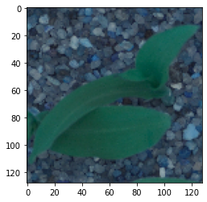

```python
plt.imshow(X_validate_img,cmap='gray')
```

```python
X_validate_std = X_validate_img/255.0
```

```python
X_validate_std.shape = (1, 128, 128, 3)
```

```python
y_pred = model_cnn.predict(X_validate_std)
```

```python
y_pred
```

```
array([[2.2637566e-32, 1.2208068e-06, 5.3837949e-01, 3.7614218e-08,
        2.7969088e-05, 1.8183440e-02, 6.7038898e-04, 2.1366293e-07,
        1.8858793e-30, 4.4273707e-01, 2.5555160e-22, 1.4700798e-07]],
      dtype=float32)
```

```python
y_pred.max()
```

```
0.5383795
```

The output implies that it is 3rd number i.e. Common_Chickweed

The convolutional layers create feature maps that record a region of image which is ultimately broken into rectangles and sent out for nonlinear processing. IT has very High accuracy in image recognition problems. They reduce the number of units in the network (since they are many-to-one mappings).This means, there are fewer parameters to learn which reduces the chance of overfitting as the model would be less complex than a fully connected network.

Neural Networks can have a large number of free parameters (the weights and biases between interconnected units) and this gives them the flexibility to fit highly complex data (when trained correctly) that other models are too simple to fit.

-------------------------------------------------END of Part 2--------------------------------------------